# Chinese Development Projects and Leaders’ Home Regions

Evidence from Subnational Africa 2000-2021

Author

Nicole He

Published

October 26, 2026

Abstract

# 1 Introduction

African regions that produce national leaders receive more Chinese development projects than other regions. But does this advantage emerge because leaders direct resources toward their home regions after taking office, or were these regions already more likely to attract development finance? Distinguishing between these explanations matters because a pattern observed during a leader’s presidency does not necessarily originate with the presidency itself.

Research has linked political leaders’ regional origins to uneven development outcomes (Hodler & Raschky, 2014). Dreher et al. (2019) also find evidence that Chinese development finance is disproportionately directed toward the birth regions of national leaders. However, whether this advantage already exists before leaders take office remains an important question. Without examining the timing of project allocation, preexisting regional differences may be mistaken for presidential favoritism.

This paper examines Chinese development projects across 778 regions in 55 African countries from 2000 to 2021. It compares future leader-producing regions with other regions in the same country and year before their leaders take office, then examines whether project receipt increases during a leader’s time in office. World Bank projects provide a comparison, while additional analyses assess the role of capital regions.

# 2 Literature Review

## 2.1 Where Does Foreign Aid Go?

Alesina and Dollar (2000) show that foreign aid allocation reflects political and strategic interests as well as recipient countries’ needs. Colonial relationships and political alliances help explain which countries receive aid, suggesting that development assistance cannot be understood solely as a response to poverty. However, country-level allocation does not explain how projects are distributed within recipient countries. Once a donor commits to financing a country, projects must still be placed in particular regions. This distinction matters because regions differ in their proximity to national governments, infrastructure, and political institutions. If leaders disproportionately come from regions that are already well connected, those regions might receive more development projects regardless of who holds national office. My research therefore shifts the question from which countries receive aid to whether regions that eventually produce national leaders receive more Chinese projects than other regions of the same country.

## 2.2 Aid, Institutions, and Measurement

Burnside and Dollar (2000) argue that foreign aid promotes economic growth primarily in countries with sound fiscal, monetary, and trade policies. Their findings helped motivate arguments for making aid conditional on recipient governments’ policy choices. Easterly (2003), however, questions the robustness of this relationship by showing that the results are sensitive to changes in data and measurement. Together, these studies demonstrate why claims about development assistance must be tied to the specific outcome being examined. My paper does not measure whether Chinese projects improve economic growth, reduce poverty, or strengthen institutions. Instead, it examines where projects are located and when they arrive. This distinction allows me to investigate the political geography of Chinese development finance without assuming that a region receiving more projects necessarily benefits more from them.

## 2.3 The Politics of Chinese Development Finance

Research on Chinese development finance raises questions about both the scale of lending and how its consequences should be interpreted. Horn, Reinhart, and Trebesch (2021) document the extent of China’s overseas lending and show that a substantial portion is missing from commonly used international debt statistics. Bräutigam (2020) challenges the claim that Chinese lending generally operates as a deliberate debt-trap strategy, while research on debt distress emphasizes that the financial risks of Chinese lending remain important. These debates concern the motivations and consequences of Chinese finance, but they do not by themselves establish how projects are distributed among regions within a country. For that question, the location of individual projects matters. If Chinese projects are concentrated in leaders’ home regions, the next step is to determine whether that concentration reflects decisions made by leaders in office or differences between regions that existed beforehand.

## 2.4 Leaders’ Home Regions and Chinese Projects

Dreher et al. (2019) provide the closest precedent for this study. Examining Chinese aid projects in Africa, they find that regions where national leaders were born receive more Chinese aid while those leaders are in office. The relationship is stronger around executive elections and in countries with more competitive elections, a pattern consistent with leaders having incentives to direct resources toward politically important places. They also find no comparable birth-region bias in World Bank aid. These results establish an important association between leaders’ origins and the distribution of Chinese projects. However, an association observed during a leader’s tenure does not, on its own, show whether the advantage began after the leader took office. The same pattern could arise if leaders disproportionately came from regions that already attracted development projects, or if they had political influence before becoming national leaders.

This distinction creates the central question for my paper. Rather than examining only whether a leader’s home region receives more projects during the leader’s tenure, I examine whether that region was already receiving more projects before its first leader of the 2000–2021 period took office. I then trace the difference between leader-producing regions and other regions of the same countries around the year the leader arrives. If the gap emerges mainly after that year, the pattern would be consistent with favoritism associated with holding national office. If the gap is already present beforehand and remains similar afterward, the evidence would instead favor an explanation based on a pre-existing regional advantage, although it would not rule out political influence before a leader takes office.

## 2.5 Distinguishing a Head Start from an Office Effect

My study extends the home-region literature by making the timing of the difference its central focus. I first estimate the head start: the difference in the likelihood of receiving a Chinese project between regions that will produce a leader and other regions of the same country in the same year, using only the years before the leader takes office. I then use an arrival figure to examine whether the gap visibly changes around the leader’s arrival. Finally, I repeat the head-start comparison after excluding capital regions. This matters because capitals may attract development projects for reasons unrelated to a leader’s personal preferences, while leaders may also be more likely to come from these politically connected places. Together, these comparisons help assess whether the observed home-region pattern is better explained by a pre-existing advantage or by a change associated with taking office. They cannot establish that the head start is entirely nonpolitical, but they provide a more direct test of when the geographic advantage appears.

# 3 Theory

Why do regions that produce national leaders receive more development projects? One explanation emphasizes what leaders do after taking office. A second emphasizes differences that already exist between regions before their leaders enter office. Both mechanisms could generate a positive relationship between a region’s connection to national leadership and its receipt of development projects. Distinguishing between them requires separate comparisons.

## 3.1 The head start: advantages before office

Regions differ in their geographic, economic, and institutional characteristics. Some contain major cities, ports, transportation networks, universities, or administrative centers. Others have fewer connections to national institutions or face greater logistical barriers to development. These differences may influence where development projects are located, independently of whether a region’s native-born residents later become national leaders.

Regional characteristics may also influence which individuals reach national leadership. Access to education, political organizations, administrative institutions, and national networks may differ across regions. As a result, the geographic origins of national leaders may not be random. The same characteristics that make a region more likely to produce a national leader could also make it more likely to receive development projects.

This possibility creates a problem for explanations that attribute the entire difference in project receipt to presidential favoritism. Suppose a region receives more projects than other regions before one of its residents becomes president. That difference cannot be explained solely by decisions the president makes after taking office. It may instead reflect advantages that predate the presidency. These advantages could be economic, institutional, geographic, or political, and the existence of a head start does not by itself identify which mechanism is responsible.

The head-start analysis therefore compares two groups during years before their first leader takes office: regions that will produce a national leader during the study period and regions that do not produce a leader during that period. The comparison is made within the same country and year, accounting for circumstances that affect all regions in a country in a given year. A positive difference indicates that leader-producing regions already have a higher probability of receiving projects before their leader enters office.

This leads to the first expectation:

**H1: Before their first national leader takes office, regions that will produce a national leader are more likely to receive Chinese development projects than other regions in the same country and year.**

The hypothesis concerns the existence of a preexisting difference, not its cause. A positive result would be consistent with the idea that leader-producing regions have a head start. It would not establish that the advantage results from corruption, political favoritism, or any single regional characteristic.

## 3.2 The office premium: changes during a leader’s time in office

A different mechanism operates when leaders influence project allocation after taking office. National leaders may have incentives to direct resources toward their home regions. Such projects could reward political supporters, strengthen personal networks, or demonstrate that the leader’s administration delivers benefits to a region with which the leader has a personal connection. Previous research on regional favoritism and Chinese development finance makes this a plausible explanation for the relationship between leaders and project allocation (Hodler and Raschky 2014; Dreher et al. 2019).

If a leader’s arrival generates an additional increase in project receipt, the region should receive projects more frequently during its leader’s time in office than during other years, after accounting for changes shared by regions in the same country and year. This is a different question from whether leader-producing regions already receive more projects than other regions. A region may begin with a high level of project receipt and experience no additional increase when its leader enters office. Alternatively, a region may have little initial advantage but experience a change during its leader’s presidency.

The office-premium analysis uses region fixed effects to account for stable differences between regions. These may include geographic features or other characteristics that do not change over the observation period. Country-year fixed effects account for changes shared by regions within the same country in a given year. The coefficient on the in-office indicator therefore captures the estimated within-region difference associated with the years when its own leader is in office, net of the shared country-year conditions included in the model.

This leads to the second expectation:

**H2: A region is more likely to receive a Chinese development project during the years when its own national leader is in office than during its other years, after accounting for region and country-year fixed effects.**

The two hypotheses are not competing versions of the same test. H1 concerns a difference between regions before the relevant leader takes office. H2 concerns a difference within regions over time. A region can have a substantial head start and a small office premium, a small head start and a large office premium, or both. The design estimates these quantities separately rather than assuming that one is the remainder of the other.

## 3.3 Comparing Chinese projects with World Bank projects

A further question is whether the head start is specific to Chinese development finance. If leader-producing regions have advantages that make them more likely to receive projects from development lenders generally, a similar preexisting difference may appear in World Bank projects. This would be consistent with a broader relationship between regional characteristics and project allocation rather than a pattern unique to Chinese financing.

A World Bank comparison cannot serve as a perfect test of whether project allocation is political. Recipient governments may influence the location of projects financed by different lenders, and the institutions, project-selection processes, and time periods may differ. Nevertheless, examining both sources of finance can show whether the preexisting regional difference appears in more than one project-allocation setting.

This leads to the third expectation:

**H3: Regions that will produce a national leader are more likely to receive World Bank projects before their first leader takes office than other regions in the same country and year.**

The World Bank analysis covers 2000–2014 because that is the available period for the project-location data used in this study. Its estimates must therefore be interpreted with this shorter time window in mind.

## 3.4 The role of capital regions

Capital regions may contribute to the observed head start. National capitals often concentrate government ministries, political institutions, transport infrastructure, and economic activity. These characteristics can increase a capital’s importance in development planning while also making it a potential source of national leaders. Capital regions may consequently have high project receipt for reasons that are not specific to the birthplace of a particular leader.

If capital regions account for part of the observed difference between leader-producing regions and other regions, excluding them should reduce the estimated head start. This comparison does not identify the causal effect of capital status, but it helps assess whether the result depends heavily on regions that contain national capitals.

This leads to the fourth expectation:

**H4: The estimated head start for Chinese development projects is smaller when capital regions are excluded.**

Together, these expectations distinguish preexisting regional advantage, changes associated with a leader’s time in office, differences across lenders, and the contribution of capital regions. The estimates are observational and should not be interpreted as definitive causal effects. Their purpose is to clarify when the regional difference appears and whether the same pattern remains across alternative comparisons.

# 4 Data

This study uses data from 778 regions across 55 African countries between 2000 and 2021. These regions are first-level administrative divisions within each country, such as provinces or other equivalent administrative units. Each observation represents one region in a particular year, creating a total of 17,116 region to year observations. Organizing the data this way allows me to compare regions within the same country and examine how the distribution of development projects changes over time.

The dataset combines information from several sources. AidData provides information on Chinese development projects, while the Political Leaders’ Affiliation Database (PLAD) provides information about the birthplaces of national leaders. AidData provides information on Chinese development projects (Custer et al. 2023). The Political Leaders’ Affiliation Database provides information on leaders’ birthplaces (Bomprezzi et al. 2024). The geographic boundaries of the regions come from geoBoundaries. Data on World Bank projects come from the World Bank’s own records of project locations. However, the World Bank data only cover the period through 2014, so the analysis using these projects is limited to the years 2000 through 2014.

The main outcome variable records whether a region received at least one Chinese project in a given year. It is coded as 1 when a project was recorded in the region and 0 when no project was recorded. Projects are assigned to the year in which China agreed to fund them, which may be earlier than the year when construction actually began. I use a yes-or-no measure instead of the dollar value of projects because funding amounts are missing for many Chinese grants. This approach allows the analysis to include projects even when their financial value is unavailable.

Each region-year observation is assigned to one of four states based on whether the region produces a national leader and when that leader serves:

- **Produces no leader:** No person born in the region becomes the country’s national leader between 2000 and 2021.
- **Before its first leader:** The region produces a national leader during 2000–2021, but the observation falls before that leader first takes office.
- **Its first leader in office:** The region’s first leader of the period is serving as national leader in that year.
- **After its first leader:** The region’s first leader of the period has left office, and the observation falls afterward.

The four states contain 14,190, 974, 1,023, and 929 region-year observations, respectively, for a total of 17,116 observations.

A capital region is a region that contains a country’s national capital. There are 57 capital regions in the dataset. Some countries, such as South Africa, have more than one capital, while the data do not record a capital region for four countries.

There are two important limitations to these data. First, only about 44% of Chinese projects in Africa can be assigned to a specific region, so some projects cannot be included in the regional analysis. Second, “produces no leader” refers only to the period from 2000 to 2021. It does not mean that no leader from that region has ever held office.

Figure 1 shows the data before any results. Panel A shows how many Chinese projects each region received between 2000 and 2021, with regions that received none in grey. Panel B shows the national capitals. Panel C shows where the leaders were born.

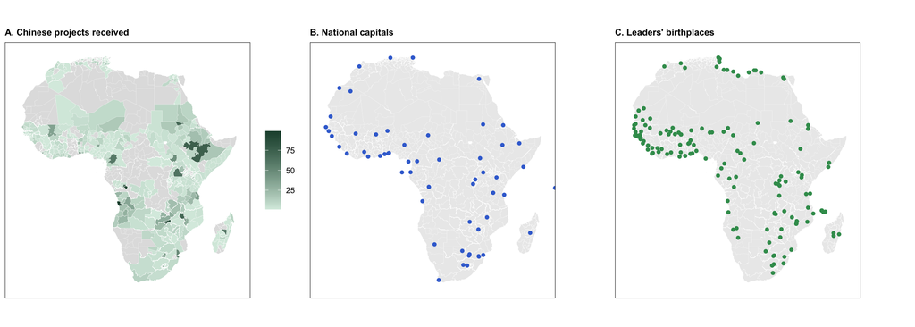

Figure 1: Panel A: total Chinese projects each region received, 2000-2021 (grey: none). Panel B: national capitals. Panel C: birthplaces of national leaders.

```r
regions  <- readRDS("data/final/regions.rds")
capitals <- readRDS("data/final/capitals.rds")
births   <- read.csv("data/final/leader_birthplaces.csv") %>%
  st_as_sf(coords = c("longitude", "latitude"), crs = 4326)

# Panel A: total Chinese projects per region
projects_per_region <- region_panel %>%
  group_by(region_id) %>%
  summarise(total_projects = sum(n_all), .groups = "drop")

map_a_data <- left_join(regions, projects_per_region, by = "region_id") %>%
  mutate(total_projects = ifelse(is.na(total_projects), 0, total_projects))

frame <- coord_sf(xlim = c(-19, 52), ylim = c(-36, 38))

map_theme <- theme_bw() +
  theme(axis.text = element_blank(), axis.ticks = element_blank(),
        panel.grid = element_blank(),
        plot.title = element_text(face = "bold", size = 10))

map_a <- ggplot() +
  geom_sf(data = filter(map_a_data, total_projects == 0),
          fill = "grey88", color = "white", linewidth = 0.05) +
  geom_sf(data = filter(map_a_data, total_projects > 0),
          aes(fill = total_projects), color = "white", linewidth = 0.05) +
  scale_fill_gradient(low = "#d9ece1", high = "#1f4d3a", name = NULL) +
  frame + labs(title = "A. Chinese projects received") + map_theme

map_b <- ggplot() +
  geom_sf(data = regions, fill = "grey92", color = "white", linewidth = 0.05) +
  geom_sf(data = capitals, color = "#3b6fd4", size = 1.5) +
  frame + labs(title = "B. National capitals") + map_theme

map_c <- ggplot() +
  geom_sf(data = regions, fill = "grey92", color = "white", linewidth = 0.05) +
  geom_sf(data = births, color = "#3a9a5b", size = 1.5) +
  frame + labs(title = "C. Leaders' birthplaces") + map_theme

ggpubr::ggarrange(
  map_a, map_b, map_c,
  ncol = 3,
  nrow = 1,
  widths = c(1.3, 1.3, 1.3),
  align = "hv",
  common.legend = FALSE
)
```

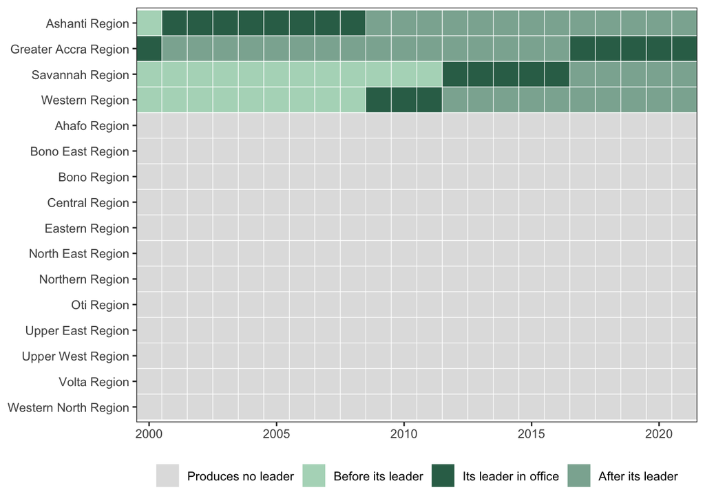

Figure 2: Ghana’s regions by year, 2000–2021. Each row represents a region, and each square represents a year, colored according to the region’s leadership state. Four of Ghana’s 16 regions produce a national leader during the study period; the remaining 12 serve as examples of regions that produce no leader during this period.

```r
ghana <- region_panel %>%
  filter(iso3 == "GHA") %>%
  mutate(state = factor(state, levels = c("never", "before", "during", "after")))

# Regions that produce a leader first, then the rest alphabetically
region_order <- ghana %>%
  distinct(region_name, ever_leader) %>%
  arrange(desc(ever_leader), region_name) %>%
  pull(region_name)

ghana <- ghana %>%
  mutate(region_name = factor(region_name, levels = rev(region_order)))

ggplot(ghana, aes(x = year, y = region_name, fill = state)) +
  geom_tile(color = "white") +
  scale_fill_manual(
    values = c("never" = "grey88", "before" = "#b2d8c2",
               "during" = "#336e57", "after" = "#8cb0a0"),
    labels = c("Produces no leader", "Before its leader",
               "Its leader in office", "After its leader")
  ) +
  scale_x_continuous(breaks = seq(2000, 2020, by = 5), expand = c(0, 0)) +
  labs(x = NULL, y = NULL, fill = NULL) +
  theme_bw() +
  theme(legend.position = "bottom", panel.grid = element_blank())
```

Figure 2 illustrates how the four states are assigned across regions and years using Ghana as an example, each row represents one of Ghana’s 16 regions, and each square represents one year between 2000 and 2021. The color of each square indicates whether the region has not produced a national leader, is before its first leader’s time in office, has a leader in office, or is after that leader has left office.

Ghana is a useful example because four of its 16 regions produce a national leader during the study period. The Savannah row illustrates how a single region’s status can change over time as a leader takes office and later leaves. The other 12 rows represent regions that do not produce a leader during the study period, allowing the reader to see how the comparison group is classified across the same years. The figure makes clear that these categories describe a region’s relationship to national leadership over time, rather than four permanently distinct types of region.

# 5 Methods

The approach follows the timing comparison in Dinas et al. (2019).

## 5.1 Measuring the head start

The first part of the analysis examines whether regions that eventually produce a national leader receive more Chinese projects than other regions of the same country before that leader takes office. The main regression is represented by the following equation:

$$\text{Project}_{rt} = \beta \cdot \text{FutureLeaderRegion}_{r} + \text{CountryYear}_{ct} + \varepsilon_{rt}$$

In this equation, Project is coded as 1 if region *r* received a Chinese project in year *t* and 0 otherwise. FutureLeaderRegion is coded as 1 for regions that produce a national leader between 2000 and 2021. The coefficient β measures the head start associated with these regions. The analysis uses only the years before the first leader from the region took office. During these years, no leader from one of the regions being studied was serving as the country’s leader, so a difference between the two groups cannot be explained by a sitting leader directing projects toward their home region.

CountryYear represents a country-year fixed effect. This means that each region is compared with other regions in the same country during the same year. This comparison is important because Chinese development projects may vary substantially across countries and over time. The fixed effects account for differences between countries and changes from one year to another. The error term, ε, represents other factors that may affect whether a project arrives in a region.

Because the outcome variable is binary, the coefficient β is interpreted in percentage points. For example, a coefficient of 0.10 represents a 10-percentage-point difference in the probability of receiving a project in a given year. Standard errors are clustered by country because regions within the same country may not be independent of one another. A government may negotiate with China at the national level, and the resulting decisions may affect multiple regions at the same time. Clustering the standard errors by country accounts for this possibility.

The same regression is also estimated using World Bank projects instead of Chinese projects. This comparison is limited to the years 2000 through 2014, when World Bank project-location data are available.

## 5.2 Examining what happens when a leader takes office

The second part of the analysis examines whether the difference in project access changes when a leader takes office. Each region that produces a leader is aligned around the year that its first leader of the period took office, which is called year 0. The analysis follows these regions for six years before and six years after that year. This approach is similar to the method used by Dinas et al. (2019), who examined changes in political attitudes on Greek islands before and after the arrival of refugees.

For each year relative to the leader’s arrival, the figure compares the share of leader-producing regions that received a Chinese project with the share of other regions in the same country and calendar year that received a project. The 48 regions that already had one of their own leaders in office in 2000 are excluded because their leader’s arrival occurred before the beginning of the dataset. The vertical bars in the figure represent 95% confidence intervals, which show the uncertainty around each estimated average. This figure provides a visual comparison rather than a formal statistical test of whether the difference changes at year 0.

## 5.3 Removing capital regions

Finally, the head-start regression is repeated after removing regions that contain a national capital. This comparison examines whether the relationship between a region’s future leaders and its access to development projects remains when capital regions are excluded.

# 6 Findings

## 6.1 Differences across the four states

Figure 3 shows differences in the frequency of Chinese projects across regions based on their relationship to national leaders. Regions that produce no leader received a Chinese project in approximately 14% of the years in the dataset. By comparison, regions that eventually produce a leader received projects in approximately 25% of the years before their first leader took office. The other two categories show the project rates while the leader is in office and after the leader leaves office. These differences suggest that regions that produce national leaders may have an advantage in attracting Chinese projects even before their leaders take power. Figure 3 shows bar heights without confidence intervals, so it cannot settle anything on its own. The comparison is made properly in Figure 5.

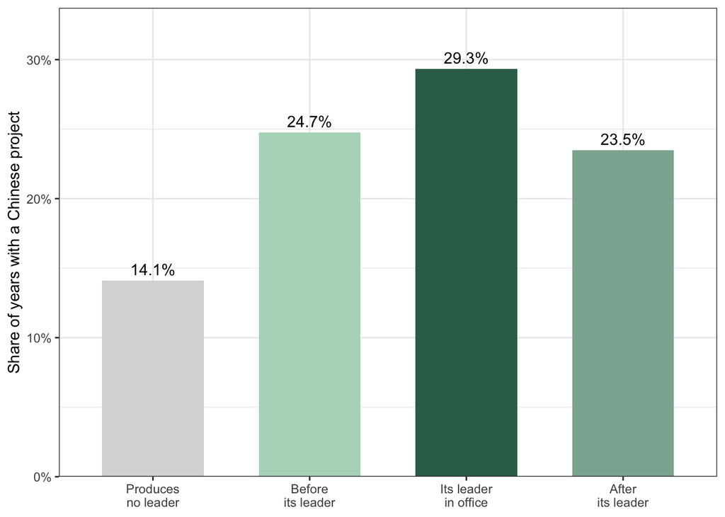

Figure 3: Share of years with a Chinese project, by the region’s state. The first two bars and the last two come from different regions and different years.

```r
fourstates_data <- region_panel %>%
  group_by(state) %>%
  summarise(share_chinese = mean(got_any_chinese), .groups = "drop") %>%
  mutate(state = factor(state, levels = c("never", "before", "during", "after")))

ggplot(fourstates_data, aes(x = state, y = share_chinese, fill = state)) +
  geom_col(width = 0.65, show.legend = FALSE) +
  geom_text(aes(label = scales::percent(share_chinese, accuracy = 0.1)),
            vjust = -0.5) +
  scale_x_discrete(labels = c("Produces\nno leader", "Before\nits leader",
                              "Its leader\nin office", "After\nits leader")) +
  scale_fill_manual(values = c("never" = "grey85", "before" = "#b2d8c2",
                               "during" = "#336e57", "after" = "#8cb0a0")) +
  scale_y_continuous(labels = scales::percent,
                     expand = expansion(mult = c(0, 0.15))) +
  labs(x = NULL, y = "Share of years with a Chinese project") +
  theme_bw()
```

## 6.2 The Chinese project head start

Column 1 of the head-start table shows that, in the years before their first leader took office, regions that would produce a national leader were 12.1 percentage points more likely to receive a Chinese project in a given year than regions of the same country and year that produced no leader. This difference is statistically significant at the 1% level. Since the regression only includes years before the first leader of the period takes office, no sitting leader from these regions could have been responsible for the difference during the years included in the analysis. The result therefore shows that the advantage existed before the leader’s time in office.

## 6.3 Comparing the results with World Bank projects

The World Bank results provide a comparison with another major development lender. In column 3, regions that would produce a national leader were 4.9 percentage points more likely to receive a World Bank project than other regions of the same country and year during the period from 2000 to 2014. This estimate is statistically significant at the 5% level. The World Bank result points in the same direction as the Chinese project result, although the size of the difference is smaller.

The World Bank is not completely separate from politics, since recipient governments can influence where its projects are located. Therefore, the shared pattern suggests that the head start is not unique to Chinese lending. However, it does not demonstrate that politics plays no role in the distribution of either Chinese or World Bank projects.

## 6.4 What happens when the leader takes office?

The arrival figure compares the share of regions that produce a national leader and the share of other regions in the same countries and years that receive Chinese projects. Before the leader takes office, the two groups already differ: in year −2, 32% of leader-producing regions received a Chinese project, compared with 16% of other regions. Their 95% confidence intervals do not overlap (22–43% versus 11–21%). In the other 12 years shown, the intervals overlap. This exception means the figure does not support the assumption that the two groups followed parallel trends before the leader’s arrival. The preexisting difference therefore limits any causal interpretation of changes around year 0.

There is also no visible jump in project access when the leader takes office. The average gap between the two groups is 0.106 before year 0 and 0.095 from year 0 onward, indicating that the difference remains similar after the leader’s arrival. Each point is based on only about 60 to 83 regions, so the figure can show that no large jump is visible but cannot rule out a smaller change. The preexisting gap is consistent with a head start for leader-producing regions, which is measured directly in Table 1; the table estimates the size of the difference, while the arrival figure shows when it appears.

## 6.5 Why is the “in office” bar taller?

The four-states figure shows that the share of regions receiving Chinese projects rises from approximately 25% before a leader takes office to approximately 29% while that leader is in office. One possible explanation is that the increase reflects changes in project activity over time rather than a direct effect of the leader’s arrival.

Among the 85 regions that have both years before a leader’s arrival and years during that leader’s time in office, the average share receiving a Chinese project increases from 24.7%, or about 25%, to 29.9%, or about 30%. The years before the leader’s arrival have an average year of 2007, while the years during the leader’s time in office have an average year of 2013. During these same periods, the share of projects received by other regions of the same countries increases from approximately 14% to 18%. This represents a rise of about 4 percentage points among the other regions, compared with a rise of about 5 percentage points among the leader-producing regions.

Comparing regions within the same country and year accounts for this shared increase over time. A simple comparison of the four states does not make that adjustment, which is why the “in office” bar may appear higher even when the more carefully controlled comparison does not show a new increase after the leader takes office.

## 6.6 The role of capital regions

These results are consistent with the possibility that capital regions contribute to the overall difference between regions that produce leaders and those that do not. Leaders come from capital regions more often: approximately 17% of leader-producing regions contain a capital, compared with about 5% of other regions. Capital regions also receive Chinese projects in about half of all years, with project rates of approximately 48% for regions that produce no leader and 53% for regions that produce a leader. By comparison, the corresponding rates outside capital regions are approximately 12% and 18%.

These patterns help explain why removing capital regions reduces the estimated head start. However, the analysis does not establish that the estimates with and without capitals are statistically different from one another.

## 6.7 Summary of findings

Taken together, the results show that regions that eventually produce national leaders receive more Chinese projects than other regions of the same countries and years. This difference is already visible before the leaders take office, which suggests that the advantage cannot be explained entirely by leaders directing projects toward their home regions after gaining power. The arrival figure shows no visible jump in the gap when leaders take office. The results also show that removing capital regions roughly halves the head start, suggesting that regional characteristics associated with capitals may be an important part of the relationship. These findings do not rule out political influence, but they indicate that the geographic advantages of leader-producing regions deserve attention alongside explanations based on favoritism.

```r
head_start_data <- region_panel %>%
  filter(state %in% c("never", "before"))

# Chinese projects, all regions
model_headstart <- feols(
  got_any_chinese ~ ever_leader | country_year,
  data = head_start_data,
  cluster = ~iso3
)

# Chinese projects, capitals dropped
model_headstart_nocap <- feols(
  got_any_chinese ~ ever_leader | country_year,
  data = head_start_data %>% filter(is_capital == 0),
  cluster = ~iso3
)

# World Bank projects, all regions (World Bank data stop in 2014)
model_wb <- feols(
  got_worldbank ~ ever_leader | country_year,
  data = head_start_data %>% filter(year <= 2014),
  cluster = ~iso3
)

# World Bank projects, capitals dropped (2000-2014)
model_wb_nocap <- feols(
  got_worldbank ~ ever_leader | country_year,
  data = head_start_data %>% filter(year <= 2014, is_capital == 0),
  cluster = ~iso3
)
```

```r
modelsummary(
  list("China, all regions"      = model_headstart,
       "China, no capitals"      = model_headstart_nocap,
       "World Bank, all regions" = model_wb,
       "World Bank, no capitals" = model_wb_nocap),
  stars = TRUE,
  coef_map = c("ever_leader" = "Region will produce a leader"),
  gof_omit = "R2|AIC|BIC|RMSE|Std.Errors"
)
```

Table 1: The head start: how much more likely a region that will produce a leader is to receive a project than other regions of the same country in the same year, before its first leader takes office. World Bank columns use 2000-2014 only. Standard errors clustered by country in parentheses.

|  | China, all regions | China, no capitals | World Bank, all regions | World Bank, no capitals |
| --- | --- | --- | --- | --- |
| Region will produce a leader | 0.121** | 0.060+ | 0.049* | 0.022 |
|  | (0.039) | (0.033) | (0.019) | (0.017) |
| Num.Obs. | 15132 | 14165 | 10545 | 9839 |
| FE: country_year | X | X | X | X |

+ p < 0.1, * p < 0.05, ** p < 0.01, *** p < 0.001

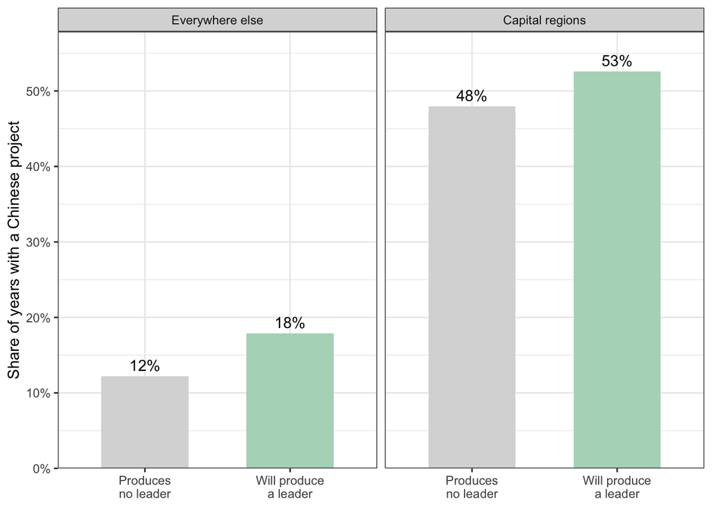

Figure 4: Share of years with a Chinese project, in capital regions (right) and everywhere else (left). Each panel compares regions that produce no leader with regions that will produce one, using only the years before a region’s first leader of 2000-2021 takes office.

```r
capitals_data <- head_start_data %>%
  group_by(is_capital, state) %>%
  summarise(share_chinese = mean(got_any_chinese), .groups = "drop") %>%
  mutate(
    state = factor(state, levels = c("never", "before")),
    is_capital = factor(is_capital, levels = c(0, 1),
                        labels = c("Everywhere else", "Capital regions"))
  )

ggplot(capitals_data, aes(x = state, y = share_chinese, fill = state)) +
  geom_col(width = 0.6, show.legend = FALSE) +
  geom_text(aes(label = scales::percent(share_chinese, accuracy = 1)), vjust = -0.5) +
  facet_wrap(~ is_capital) +
  scale_x_discrete(labels = c("Produces\nno leader", "Will produce\na leader")) +
  scale_fill_manual(values = c("never" = "grey85", "before" = "#b2d8c2")) +
  scale_y_continuous(labels = scales::percent,
                     expand = expansion(mult = c(0, 0.1))) +
  labs(x = NULL, y = "Share of years with a Chinese project") +
  theme_bw()
```

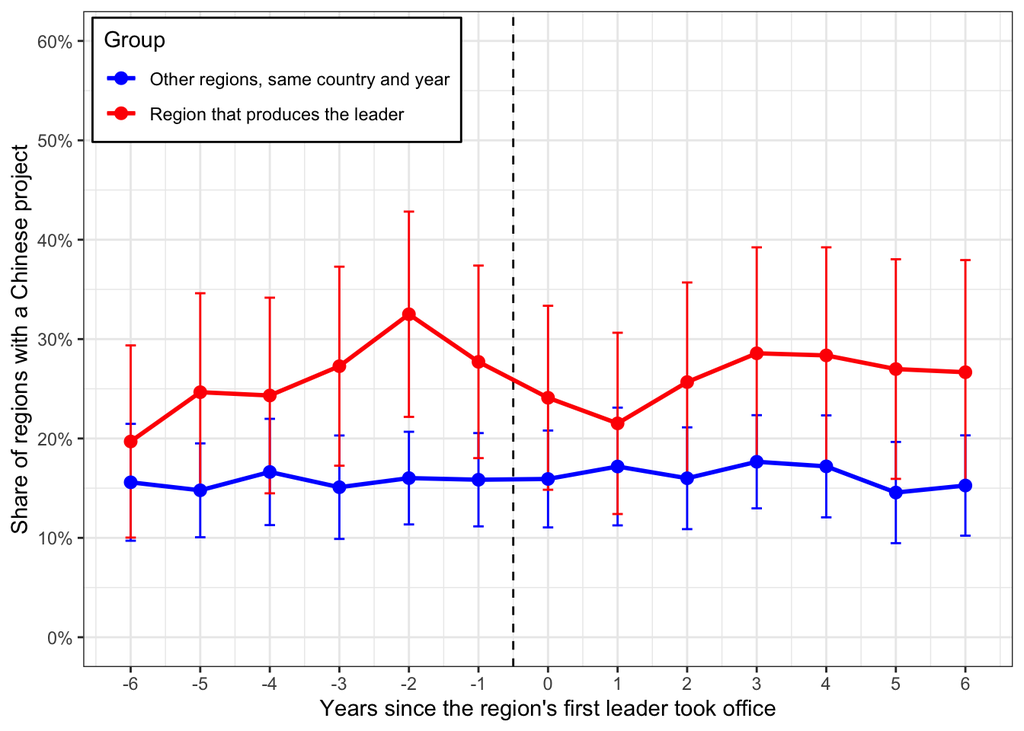

Figure 5: Share of regions with a Chinese project, by years since the region’s first leader of 2000-2021 took office (year 0). Red: regions that produce that leader. Blue: other regions of the same countries in the same years. Vertical bars are 95% confidence intervals.

```r
# THE BLUE LINE'S NUMBERS: for every country in every year, the share of its
# regions that produce no leader and received a Chinese project that year.
other_regions_by_country_year <- region_panel %>%
  filter(state == "never") %>%
  group_by(country_year) %>%
  summarise(share_other_regions = mean(got_any_chinese), .groups = "drop")

# THE RED LINE'S REGIONS: regions that produce a leader whose first leader took
# office after 2000, followed for six years either side of year 0.
arrival_rows <- region_panel %>%
  filter(ever_leader == 1, first_leader_year > 2000) %>%
  mutate(years_since_leader = year - first_leader_year) %>%
  filter(years_since_leader >= -6, years_since_leader <= 6) %>%
  left_join(other_regions_by_country_year, by = "country_year") %>%
  filter(!is.na(share_other_regions))

# BOTH GROUPS IN ONE TABLE
arrival_data <- bind_rows(
  data.frame(group = "Other regions, same country and year",
             years_since_leader = arrival_rows$years_since_leader,
             share_with_project = arrival_rows$share_other_regions),
  data.frame(group = "Region that produces the leader",
             years_since_leader = arrival_rows$years_since_leader,
             share_with_project = arrival_rows$got_any_chinese))
# Average, standard error and 95% confidence interval for each group and year
arrival_summary <- arrival_data %>%
  group_by(group, years_since_leader) %>%
  summarise(mean_share = mean(share_with_project),
            se = sd(share_with_project) / sqrt(n()),
            ci_low = mean_share - 1.96 * se,
            ci_high = mean_share + 1.96 * se,
            .groups = "drop")

ggplot(arrival_summary,
       aes(x = years_since_leader, y = mean_share, color = group, group = group)) +
  geom_vline(xintercept = -0.5, linetype = "dashed") +
  geom_errorbar(aes(ymin = ci_low, ymax = ci_high), width = 0.15) +
  geom_line(linewidth = 1) +
  geom_point(size = 2.5) +
  scale_color_manual(values = c("Other regions, same country and year" = "blue",
                                "Region that produces the leader" = "red")) +
  scale_x_continuous(breaks = -6:6) +
  scale_y_continuous(limits = c(0, 0.6), breaks = seq(0, 0.6, by = 0.1),
                     labels = scales::percent) +
  labs(x = "Years since the region's first leader took office",
       y = "Share of regions with a Chinese project",
       color = "Group") +
  theme_bw() +
  theme(legend.position = "inside",
        legend.position.inside = c(0.01, 0.99),
        legend.justification = c(0, 1),
        legend.background = element_rect(color = "black"))
```

# 7 Discussion

## 7.1 A Head Start Rather Than a Sudden Political Reward

The findings provide stronger support for a pre-existing regional advantage than for a sudden increase in Chinese development projects when a region’s native leader takes office. Future leader-producing regions already had a substantial advantage in Chinese project allocation before their leaders took office. The 12.1 percentage point difference suggests that the concentration of Chinese projects in leaders’ home regions cannot be explained entirely by favoritism from sitting presidents.

This finding adds a temporal dimension to Dreher et al. (2019), who identify a relationship between leaders’ birth regions and Chinese aid during their time in office. Rather than challenging their findings, this analysis asks when the geographic advantage first appears. The results suggest that the concentration of Chinese projects in leaders’ home regions cannot be understood solely as a reward delivered after they assume power. Some of the advantage is already present beforehand.

The arrival figure shows no visible jump in the project-receipt gap when a leader takes office. The average gap is 10.6 percentage points before arrival and 9.5 percentage points during or after arrival. The gap does not visibly increase at year zero, when the leader first takes office. In addition, the confidence intervals overlap in most of the years examined. These patterns do not provide clear evidence of a new advantage emerging precisely when a leader assumes office. However, they do not establish that leaders have no influence over project allocation. Leaders may exert influence before formally taking office, and the descriptive comparison cannot isolate the causal effect of assuming power.

## 7.2 Regional Advantage Beyond China and the Role of Capitals

The World Bank comparison provides further context. Future leader-producing regions were 4.9 percentage points more likely to receive a World Bank project before their leaders took office, a statistically significant relationship. This suggests that the pre-existing advantage is not unique to Chinese development finance. The geographic distribution of projects from different sources may reflect common characteristics of regions that are economically active, politically important, or institutionally connected. At the same time, the World Bank estimate is smaller than the Chinese estimate, and the two estimates alone do not establish that the difference between them is statistically significant.

Capital regions are an important part of this pattern. Capitals are much more likely to receive projects and are also more likely to produce national leaders. When capital regions are excluded, the estimated Chinese head start falls from 12.1 to 6.0 percentage points, and the estimate is only statistically significant at the 10% level. The World Bank head-start estimate also becomes smaller and statistically insignificant when capitals are excluded. Excluding capital regions reduces the estimated Chinese head start from 12.1 to 6.0 percentage points, showing that the relationship is substantially smaller outside capitals, although the analysis does not establish precisely how much of the relationship is caused by capital status.

Several limitations qualify these conclusions. First, the analysis identifies whether a region receives at least one project in a given year, not the total value, size, or strategic importance of the projects it receives. Second, the location data do not identify every Chinese project, limiting the geographic coverage of the outcome. Third, regions are broad units of analysis. A leader could favor a particular district, community, or contractor within a region without creating a detectable change in the region-level measure. Finally, the association between future leader regions and project receipt may reflect unobserved differences between regions or political influence that predates a leader’s presidency.Overall, the findings favor a pre-existing regional head start over a sudden increase in project allocation when leaders take office. However, they cannot determine whether the head start reflects economic and institutional advantages, political influence that predates a presidency, or a combination of both

# 8 Conclusion

Do Chinese development projects follow presidents home, or do presidents and projects come from the same kinds of places? The findings suggest that the relationship begins before leaders take office. Regions that later produce national leaders are more likely to receive Chinese development projects even before those leaders assume power, and the observed gap does not visibly increase at the moment they take office. The presence of a similar, though smaller, pre-office relationship in World Bank projects further suggests that the pattern is not exclusive to Chinese development finance.

These findings complicate explanations that attribute the concentration of Chinese projects in leaders’ home regions entirely to presidential favoritism. Political leaders can influence where development finance goes, but their home regions can also possess advantages that make them attractive project destinations before they reach national office. The role of capital regions reinforces this point: some of the observed relationship reflects the distinctive position of capitals, which are both common birthplaces of national leaders and frequent recipients of development projects.

The analysis does not rule out political favoritism. Its region-level measure cannot capture every decision about project size, location within a region, or the distribution of contracts, and its descriptive comparisons cannot establish the causal effect of a leader’s arrival. Instead, its contribution is to show why the timing of geographic advantage matters. Identifying which regions receive projects during a leader’s tenure is not the same as establishing when that advantage began or why it exists.

Understanding the allocation of development finance therefore requires attention not only to leaders’ decisions, but also to the regional conditions that precede them. Future research could examine project values, more precise subregional locations, and changes in political influence before and after leaders take office. These approaches would help distinguish whether development finance follows political power, reinforces existing regional advantages, or does both. Ultimately, the question is not simply whether leaders’ home regions receive more projects, but whether those regions were already positioned to receive them before their leaders gained power.

# 9 AI transparency statement

I used ChatGPT to solve structure code errors and revision aid to help organize sections, clarify explanations, and improve the readability of the paper. I am responsible for the research question, data analysis, interpretation of the findings, verification of sources, and final submitted version. I reviewed and revised the text to ensure that it accurately represents my work and that I can explain and defend the paper’s claims and methods.

## References

Bomprezzi, Pietro, Axel Dreher, Andreas Fuchs, et al. 2024. *The Political Leaders’ Affiliation Database (PLAD)*. Harvard Dataverse. https://doi.org/10.7910/DVN/YUS575.

Custer, Samantha, Axel Dreher, Thai-Binh Elston, et al. 2023. *Tracking Chinese Development Finance: An Application of AidData’s TUFF 3.0 Methodology*. AidData, a research lab at William & Mary.

Dinas, Elias, Konstantinos Matakos, Dimitrios Xefteris, and Dominik Hangartner. 2019. “Waking up the Golden Dawn: Does Exposure to the Refugee Crisis Increase Support for Extreme-Right Parties?” *Political Analysis* 27 (2): 244–54.